[figure not shown]

# Exercises

## Bike store sales

[figure not shown]

## Hands on!

```python
import numpy as np
import pandas as pd
import matplotlib.pyplot as plt

%matplotlib inline
```

```python
sales = pd.read_csv(
    'data/sales_data.csv',
    parse_dates=['Date'])
```

```python
sales.head()
```

|  | Date | Day | Month | Year | Customer_Age | Age_Group | Customer_Gender | Country | State | Product_Category | Sub_Category | Product | Order_Quantity | Unit_Cost | Unit_Price | Profit | Cost | Revenue |
| --- | --- | --- | --- | --- | --- | --- | --- | --- | --- | --- | --- | --- | --- | --- | --- | --- | --- | --- |
| 0 | 2013-11-26 | 26 | November | 2013 | 19 | Youth (<25) | M | Canada | British Columbia | Accessories | Bike Racks | Hitch Rack - 4-Bike | 8 | 45 | 120 | 590 | 360 | 950 |
| 1 | 2015-11-26 | 26 | November | 2015 | 19 | Youth (<25) | M | Canada | British Columbia | Accessories | Bike Racks | Hitch Rack - 4-Bike | 8 | 45 | 120 | 590 | 360 | 950 |
| 2 | 2014-03-23 | 23 | March | 2014 | 49 | Adults (35-64) | M | Australia | New South Wales | Accessories | Bike Racks | Hitch Rack - 4-Bike | 23 | 45 | 120 | 1366 | 1035 | 2401 |
| 3 | 2016-03-23 | 23 | March | 2016 | 49 | Adults (35-64) | M | Australia | New South Wales | Accessories | Bike Racks | Hitch Rack - 4-Bike | 20 | 45 | 120 | 1188 | 900 | 2088 |
| 4 | 2014-05-15 | 15 | May | 2014 | 47 | Adults (35-64) | F | Australia | New South Wales | Accessories | Bike Racks | Hitch Rack - 4-Bike | 4 | 45 | 120 | 238 | 180 | 418 |

[figure not shown]

### What's the mean of `Customers_Age`?

```python
# your code goes here
```

```
35.91921157861212
```

Go ahead and show a **density (KDE)** and a **box plot** with the `Customer_Age` data:

```python
# your code goes here
```

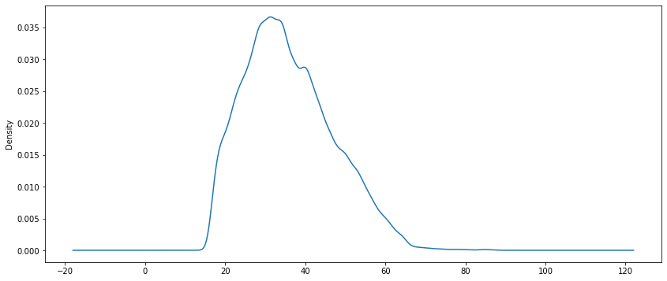

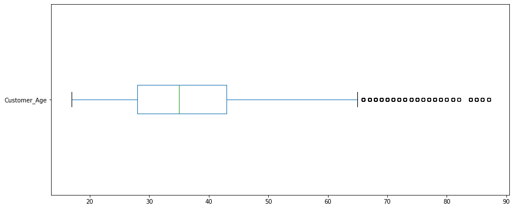

[figure not shown]

### What's the mean of `Order_Quantity`?

```python
# your code goes here
```

```
11.901659648253654
```

Go ahead and show a **histogram** and a **box plot** with the `Order_Quantity` data:

```python
# your code goes here
```

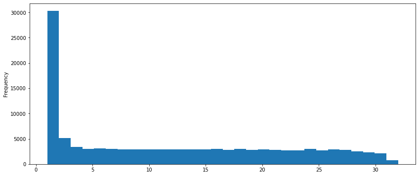

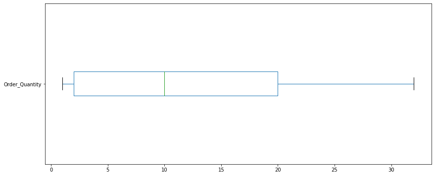

[figure not shown]

### How many sales per year do we have?

```python
# your code goes here
```

```
2016    29398
2014    29398
2015    24443
2013    24443
2012     2677
2011     2677
Name: Year, dtype: int64
```

Go ahead and show a **pie plot** with the previous data:

```python
# your code goes here
```

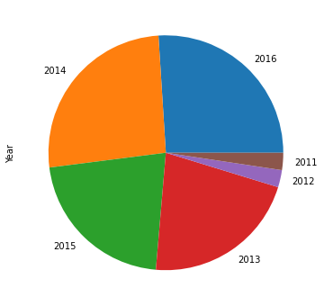

[figure not shown]

### How many sales per month do we have?

```python
# your code goes here
```

```
June         11234
December     11200
May          11128
April        10182
March         9674
January       9284
February      9022
October       8750
November      8734
August        8200
September     8166
July          7462
Name: Month, dtype: int64
```

Go ahead and show a **bar plot** with the previous data:

```python
# your code goes here
```

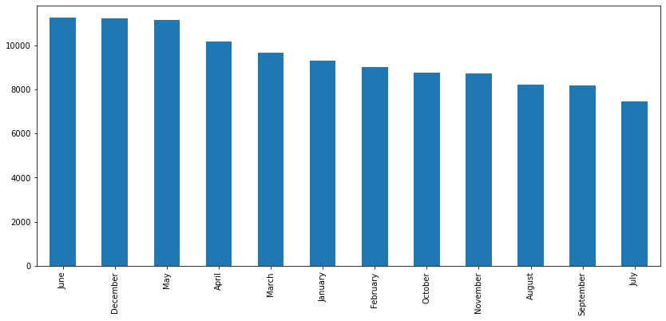

[figure not shown]

### Which country has the most sales `quantity of sales`?

```python
# your code goes here
```

```
United States    39206
Name: Country, dtype: int64
```

```
United States     39206
Australia         23936
Canada            14178
United Kingdom    13620
Germany           11098
France            10998
Name: Country, dtype: int64
```

Go ahead and show a **bar plot** of the sales per country:

```python
# your code goes here
```

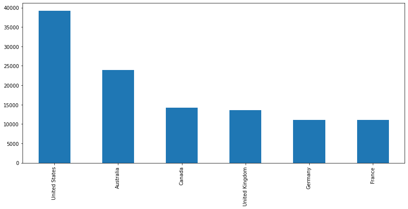

[figure not shown]

### Create a list of every product sold

```python
# your code goes here
```

```
array(['Hitch Rack - 4-Bike', 'All-Purpose Bike Stand',
       'Mountain Bottle Cage', 'Water Bottle - 30 oz.',
       'Road Bottle Cage', 'AWC Logo Cap', 'Bike Wash - Dissolver',
       'Fender Set - Mountain', 'Half-Finger Gloves, L',
       'Half-Finger Gloves, M', 'Half-Finger Gloves, S',
       'Sport-100 Helmet, Black', 'Sport-100 Helmet, Red',
       'Sport-100 Helmet, Blue', 'Hydration Pack - 70 oz.',
       'Short-Sleeve Classic Jersey, XL',
       'Short-Sleeve Classic Jersey, L', 'Short-Sleeve Classic Jersey, M',
       'Short-Sleeve Classic Jersey, S', 'Long-Sleeve Logo Jersey, M',
       'Long-Sleeve Logo Jersey, XL', 'Long-Sleeve Logo Jersey, L',
       'Long-Sleeve Logo Jersey, S', 'Mountain-100 Silver, 38',
       'Mountain-100 Silver, 44', 'Mountain-100 Black, 48',
       'Mountain-100 Silver, 48', 'Mountain-100 Black, 38',
       'Mountain-200 Silver, 38', 'Mountain-100 Black, 44',
       'Mountain-100 Silver, 42', 'Mountain-200 Black, 46',
       'Mountain-200 Silver, 42', 'Mountain-200 Silver, 46',
       'Mountain-200 Black, 38', 'Mountain-100 Black, 42',
       'Mountain-200 Black, 42', 'Mountain-400-W Silver, 46',
       'Mountain-500 Silver, 40', 'Mountain-500 Silver, 44',
       'Mountain-500 Black, 48', 'Mountain-500 Black, 40',
       'Mountain-400-W Silver, 42', 'Mountain-500 Silver, 52',
       'Mountain-500 Black, 52', 'Mountain-500 Silver, 42',
       'Mountain-500 Black, 44', 'Mountain-500 Silver, 48',
       'Mountain-400-W Silver, 38', 'Mountain-400-W Silver, 40',
       'Mountain-500 Black, 42', 'Road-150 Red, 48', 'Road-150 Red, 62',
       'Road-750 Black, 48', 'Road-750 Black, 58', 'Road-750 Black, 52',
       'Road-150 Red, 52', 'Road-150 Red, 44', 'Road-150 Red, 56',
       'Road-750 Black, 44', 'Road-350-W Yellow, 40',
       'Road-350-W Yellow, 42', 'Road-250 Black, 44',
       'Road-250 Black, 48', 'Road-350-W Yellow, 48',
       'Road-550-W Yellow, 44', 'Road-550-W Yellow, 38',
       'Road-250 Black, 52', 'Road-550-W Yellow, 48', 'Road-250 Red, 58',
       'Road-250 Black, 58', 'Road-250 Red, 52', 'Road-250 Red, 48',
       'Road-250 Red, 44', 'Road-550-W Yellow, 42',
       'Road-550-W Yellow, 40', 'Road-650 Red, 48', 'Road-650 Red, 60',
       'Road-650 Black, 48', 'Road-350-W Yellow, 44', 'Road-650 Red, 52',
       'Road-650 Black, 44', 'Road-650 Red, 62', 'Road-650 Red, 58',
       'Road-650 Black, 60', 'Road-650 Black, 58', 'Road-650 Black, 52',
       'Road-650 Black, 62', 'Road-650 Red, 44',
       "Women's Mountain Shorts, M", "Women's Mountain Shorts, S",
       "Women's Mountain Shorts, L", 'Racing Socks, L', 'Racing Socks, M',
       'Mountain Tire Tube', 'Touring Tire Tube', 'Patch Kit/8 Patches',
       'HL Mountain Tire', 'LL Mountain Tire', 'Road Tire Tube',
       'LL Road Tire', 'Touring Tire', 'ML Mountain Tire', 'HL Road Tire',
       'ML Road Tire', 'Touring-1000 Yellow, 50', 'Touring-1000 Blue, 46',
       'Touring-1000 Yellow, 60', 'Touring-1000 Blue, 50',
       'Touring-3000 Yellow, 50', 'Touring-3000 Blue, 54',
       'Touring-3000 Blue, 58', 'Touring-3000 Yellow, 44',
       'Touring-3000 Yellow, 54', 'Touring-3000 Blue, 62',
       'Touring-3000 Blue, 44', 'Touring-1000 Blue, 54',
       'Touring-1000 Yellow, 46', 'Touring-1000 Blue, 60',
       'Touring-3000 Yellow, 62', 'Touring-1000 Yellow, 54',
       'Touring-2000 Blue, 54', 'Touring-3000 Blue, 50',
       'Touring-3000 Yellow, 58', 'Touring-2000 Blue, 46',
       'Touring-2000 Blue, 50', 'Touring-2000 Blue, 60',
       'Classic Vest, L', 'Classic Vest, M', 'Classic Vest, S'],
      dtype=object)
```

Create a **bar plot** showing the 10 most sold products (best sellers):

```python
# your code goes here
```

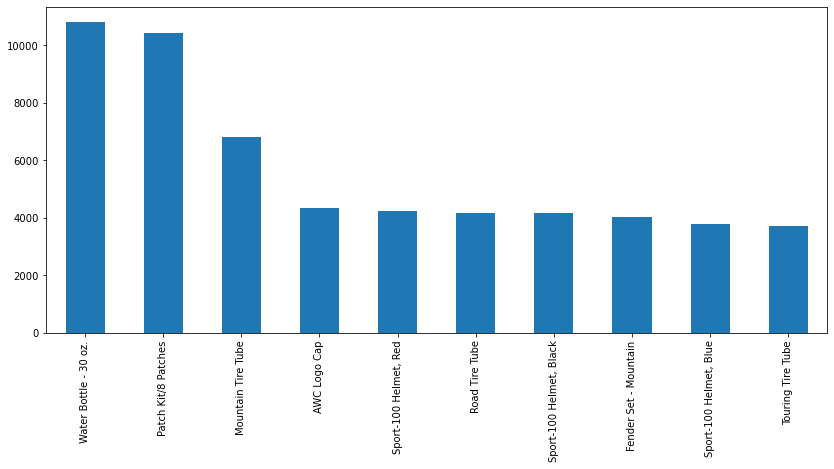

[figure not shown]

### Can you see any relationship between `Unit_Cost` and `Unit_Price`?

Show a **scatter plot** between both columns.

```python
# your code goes here
```

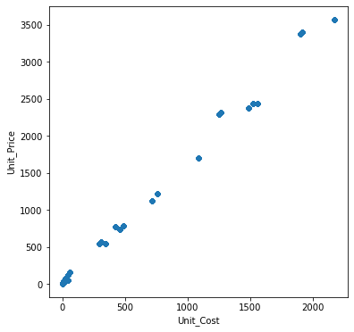

[figure not shown]

### Can you see any relationship between `Order_Quantity` and `Profit`?

Show a **scatter plot** between both columns.

```python
# your code goes here
```

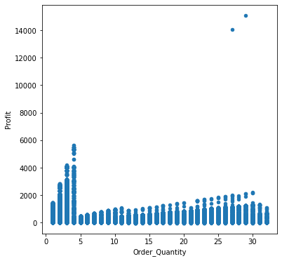

[figure not shown]

### Can you see any relationship between `Profit` per `Country`?

Show a grouped **box plot** per country with the profit values.

```python
# your code goes here
```

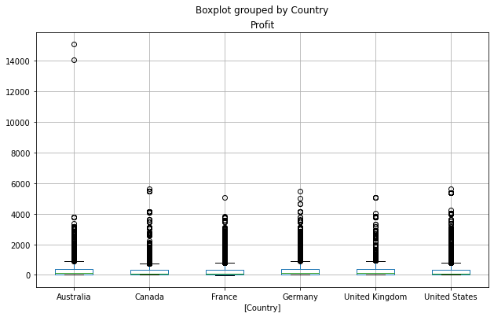

[figure not shown]

### Can you see any relationship between the `Customer_Age` per `Country`?

Show a grouped **box plot** per country with the customer age values.

```python
# your code goes here
```

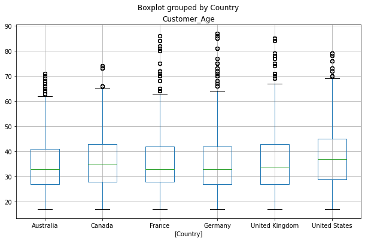

[figure not shown]

### Add and calculate a new `Calculated_Date` column

Use `Day`, `Month`, `Year` to create a `Date` column (`YYYY-MM-DD`).

```python
# your code goes here
```

```
0    2013-November-26
1    2015-November-26
2       2014-March-23
3       2016-March-23
4         2014-May-15
Name: Calculated_Date, dtype: object
```

[figure not shown]

### Parse your `Calculated_Date` column into a datetime object

```python
# your code goes here
```

```
0   2013-11-26
1   2015-11-26
2   2014-03-23
3   2016-03-23
4   2014-05-15
Name: Calculated_Date, dtype: datetime64[ns]
```

[figure not shown]

### How did sales evolve through the years?

Show a **line plot** using `Calculated_Date` column as the x-axis and the count of sales as the y-axis.

```python
# your code goes here
```

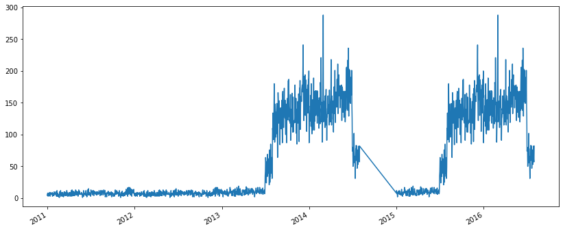

[figure not shown]

### Increase 50 U$S revenue to every sale

```python
# your code goes here
```

[figure not shown]

### How many orders were made in `Canada` or `France`?

```python
# your code goes here
```

```
25176
```

[figure not shown]

### How many `Bike Racks` orders were made from Canada?

```python
# your code goes here
```

```
104
```

[figure not shown]

### How many orders were made in each region (state) of France?

```python
# your code goes here
```

```
Seine (Paris)        2328
Seine Saint Denis    1684
Nord                 1670
Hauts de Seine       1084
Essonne               994
Yveline               954
Seine et Marne        394
Moselle               386
Loiret                382
Val d'Oise            264
Garonne (Haute)       208
Val de Marne          158
Charente-Maritime     148
Somme                 134
Loir et Cher          120
Pas de Calais          90
Name: State, dtype: int64
```

Go ahead and show a **bar plot** with the results:

```python
# your code goes here
```

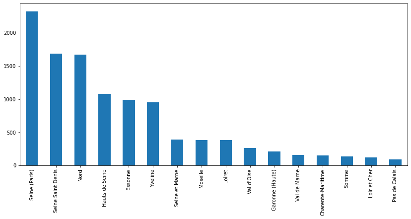

[figure not shown]

### How many sales were made per category?

```python
# your code goes here
```

```
Accessories    70120
Bikes          25982
Clothing       16934
Name: Product_Category, dtype: int64
```

Go ahead and show a **pie plot** with the results:

```python
# your code goes here
```

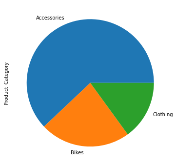

[figure not shown]

### How many orders were made per accessory sub-categories?

```python
# your code goes here
```

```
Tires and Tubes      33870
Bottles and Cages    15876
Helmets              12158
Fenders               4032
Cleaners              1802
Hydration Packs       1334
Bike Racks             592
Bike Stands            456
Name: Sub_Category, dtype: int64
```

Go ahead and show a **bar plot** with the results:

```python
# your code goes here
```

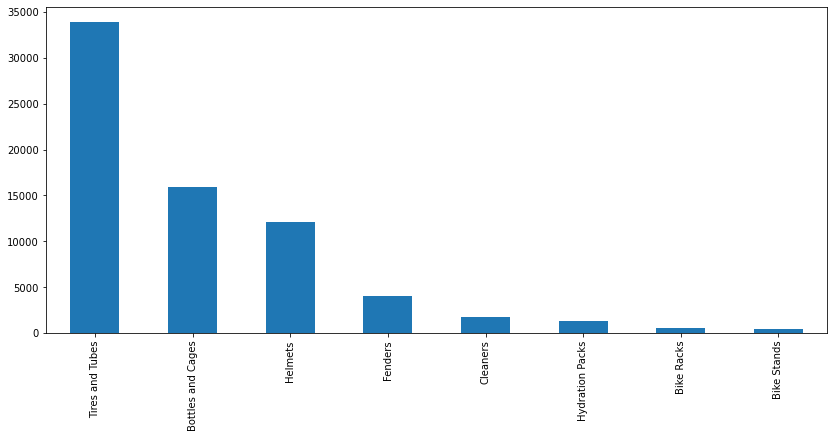

[figure not shown]

### How many orders were made per bike sub-categories?

```python
# your code goes here
```

```
Road Bikes        13430
Mountain Bikes     8854
Touring Bikes      3698
Name: Sub_Category, dtype: int64
```

Go ahead and show a **pie plot** with the results:

```python
# your code goes here
```

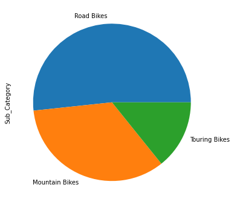

[figure not shown]

### Which gender has the most amount of sales?

```python
# your code goes here
```

```
M    58312
F    54724
Name: Customer_Gender, dtype: int64
```

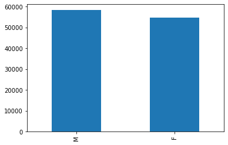

[figure not shown]

### How many sales with more than 500 in `Revenue` were made by men?

```python
# your code goes here
```

```
50
```

[figure not shown]

### Get the top-5 sales with the highest revenue

```python
# your code goes here
```

|  | Date | Day | Month | Year | Customer_Age | Age_Group | Customer_Gender | Country | State | Product_Category | Sub_Category | Product | Order_Quantity | Unit_Cost | Unit_Price | Profit | Cost | Revenue | Calculated_Date |
| --- | --- | --- | --- | --- | --- | --- | --- | --- | --- | --- | --- | --- | --- | --- | --- | --- | --- | --- | --- |
| 112073 | 2015-07-24 | 24 | July | 2015 | 52 | Adults (35-64) | M | Australia | Queensland | Clothing | Vests | Touring-1000 Yellow, 50 | 29 | 1482 | 2384 | 15096 | 42978 | 58124 | 2015-07-24 |
| 112072 | 2013-07-24 | 24 | July | 2013 | 52 | Adults (35-64) | M | Australia | Queensland | Clothing | Vests | Touring-1000 Yellow, 50 | 27 | 1482 | 2384 | 14055 | 40014 | 54119 | 2013-07-24 |
| 71129 | 2011-07-08 | 8 | July | 2011 | 22 | Youth (<25) | M | Canada | Alberta | Bikes | Road Bikes | Road-150 Red, 48 | 4 | 2171 | 3578 | 5628 | 8684 | 14362 | 2011-07-08 |
| 70307 | 2011-04-30 | 30 | April | 2011 | 44 | Adults (35-64) | M | Canada | British Columbia | Bikes | Road Bikes | Road-150 Red, 62 | 4 | 2171 | 3578 | 5485 | 8684 | 14219 | 2011-04-30 |
| 70601 | 2011-09-30 | 30 | September | 2011 | 19 | Youth (<25) | F | Canada | British Columbia | Bikes | Road Bikes | Road-150 Red, 62 | 4 | 2171 | 3578 | 5485 | 8684 | 14219 | 2011-09-30 |

[figure not shown]

### Get the sale with the highest revenue

```python
# your code goes here
```

|  | Date | Day | Month | Year | Customer_Age | Age_Group | Customer_Gender | Country | State | Product_Category | Sub_Category | Product | Order_Quantity | Unit_Cost | Unit_Price | Profit | Cost | Revenue | Calculated_Date |
| --- | --- | --- | --- | --- | --- | --- | --- | --- | --- | --- | --- | --- | --- | --- | --- | --- | --- | --- | --- |
| 112073 | 2015-07-24 | 24 | July | 2015 | 52 | Adults (35-64) | M | Australia | Queensland | Clothing | Vests | Touring-1000 Yellow, 50 | 29 | 1482 | 2384 | 15096 | 42978 | 58124 | 2015-07-24 |

[figure not shown]

### What is the mean `Order_Quantity` of orders with more than 10K in revenue?

```python
# your code goes here
```

```
3.689265536723164
```

[figure not shown]

### What is the mean `Order_Quantity` of orders with less than 10K in revenue?

```python
# your code goes here
```

```
11.914539380997528
```

[figure not shown]

### How many orders were made in May of 2016?

```python
# your code goes here
```

```
5015
```

[figure not shown]

### How many orders were made between May and July of 2016?

```python
# your code goes here
```

```
12164
```

Show a grouped **box plot** per month with the profit values.

```python
# your code goes here
```

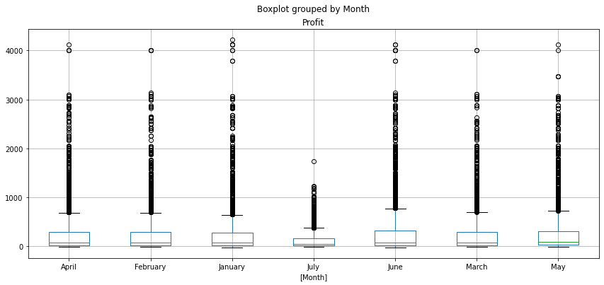

[figure not shown]

### Add 7.2% TAX on every sale `Unit_Price` within United States

```python
# your code goes here
```

[figure not shown]